# Effect of Automatic or Manual Transmission on Car Fuel Consumption

# **Author: Ziv Carthy**

## The Reasearch Questions

The two related questions we address in our analysis is: 1. Is an automatic or manual transmission better for MPG ? 2. What is the quantitative difference in MPG difference between automatic and manual transmissions.

## Exploratory Data Analsis

While the questions revolve around the type of transmission, the data includes several other variables that may influence the fuel consumption, such as weight, engine displacement, number of engin cylinders, number of carburators, etc. Chart 1 in the Appendix provides initial look at how Mile Per Galon (mpg) is effected by these variables, and how these variables relate to each others.

What emerges from this chart is that transmission (marked as“am”) has may have *some* obserable impact on fuel consumption, where manual manual transmissin cars show higher “mpg”. BUT relationship seem to be weak, as the points’ spread is large and there seem to be a lot of overlap between the categories (0=automatic, 1= manual).

*Importantly*, transimission type has some interaction with other key. For example, it shows that in our sample automatic vehicles were havier than the manual ones. Therefore, when we test the impact of transmission on mpg, we have to model in key variables as well!

## Regression Modeling

It make sense that weight will impact mpg because intuitively more energy is required to move around higher weight. Also - the larger the engine size it burns more fuel. In addition to “wt”, we’re interested to model engine size, by using displacement (but not cylinders due to redundancy). We’ll construct three linear regression models and test which is the best one to explain fuel consumption. The models are: model 1: mpg ~ transmission type (“am”) model 2: mpg ~ transmission type (“am”) + weight (“wt”) model 3: mpg ~ transmission type (“am”) + weight (“wt”) + engine displacement (“disp”)

## Analysis

#### Selected Model: Interpretation of Coefficients

Summary of model 2: is shown in Chart 5 below. The beta of the transmissin variable is -0.02 with p.value=0.988, so its not significant both from a scientific and from statistical perspectives. In this model, the transmission variable has no impact on MPG !

the wt variable, on the other hand has a beta of -5.35 with very low p.value. The model asserts that increase of 1000 pounds in car weight, results in decrease of 5.35 miles per galon.

## Appendix

### chart 1

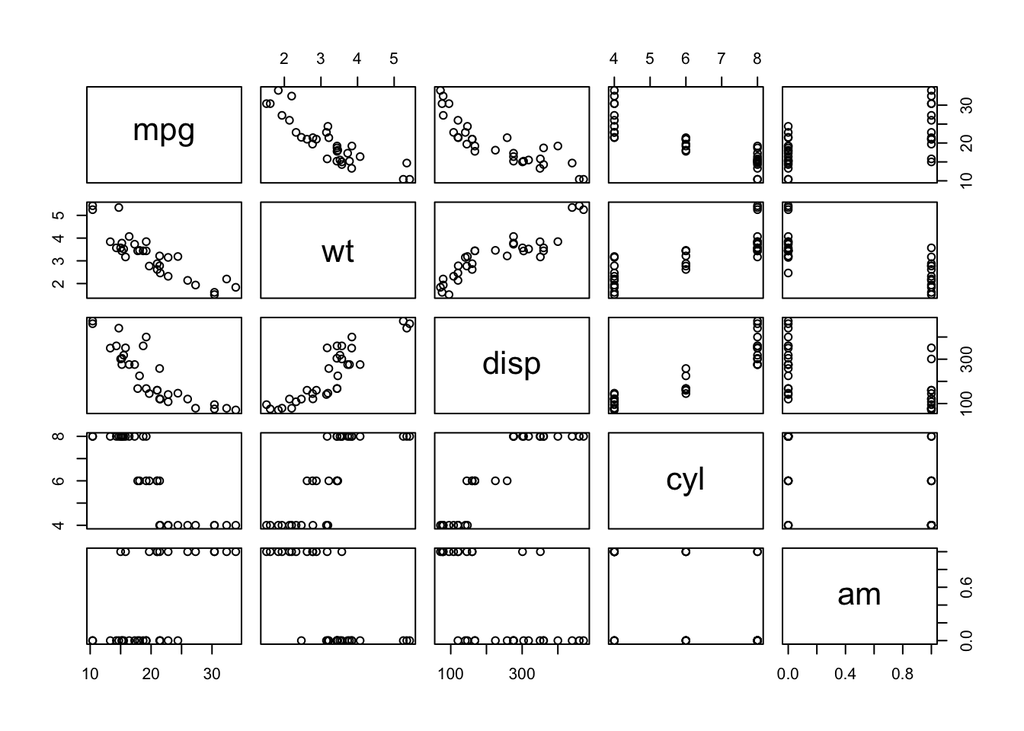

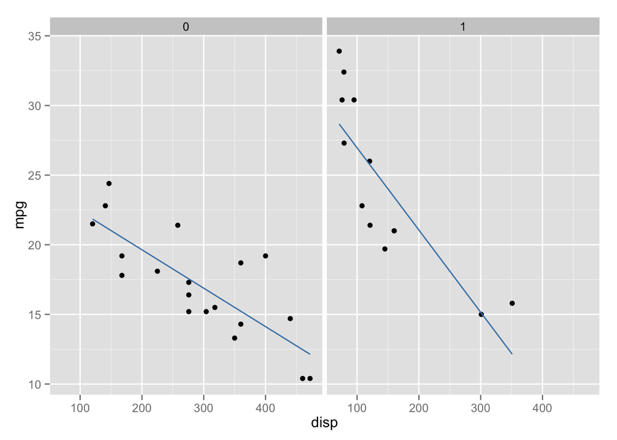

### chart 3

```
## Analysis of Variance Table
##
## Model 1: mpg ~ factor(am)
## Model 2: mpg ~ factor(am) + wt
## Model 3: mpg ~ factor(am) + wt + disp
##   Res.Df    RSS Df Sum of Sq       F    Pr(>F)
## 1     30 720.90
## 2     29 278.32  1    442.58 50.2610 1.032e-07 ***
## 3     28 246.56  1     31.76  3.6072   0.06788 .
## ---
## Signif. codes:  0 '***' 0.001 '**' 0.01 '*' 0.05 '.' 0.1 ' ' 1
```

### chart 4

```
##         Estimate Std. Error     t value     Pr(>|t|)
## [1,]  7.24493927   1.764422  4.10612698 0.0002850207
## [2,] -0.02361522   1.545645 -0.01527855 0.9879145855
```

### chart 5

```
##
## Call:
## lm(formula = mpg ~ factor(am) + wt, data = mtcars)
##
## Residuals:
##     Min      1Q  Median      3Q     Max
## -4.5295 -2.3619 -0.1317  1.4025  6.8782
##
## Coefficients:
##             Estimate Std. Error t value Pr(>|t|)
## (Intercept) 37.32155    3.05464  12.218 5.84e-13 ***
## factor(am)1 -0.02362    1.54565  -0.015    0.988
## wt          -5.35281    0.78824  -6.791 1.87e-07 ***
## ---
## Signif. codes:  0 '***' 0.001 '**' 0.01 '*' 0.05 '.' 0.1 ' ' 1
##
## Residual standard error: 3.098 on 29 degrees of freedom
## Multiple R-squared:  0.7528, Adjusted R-squared:  0.7358
## F-statistic: 44.17 on 2 and 29 DF,  p-value: 1.579e-09
```

### chart 6

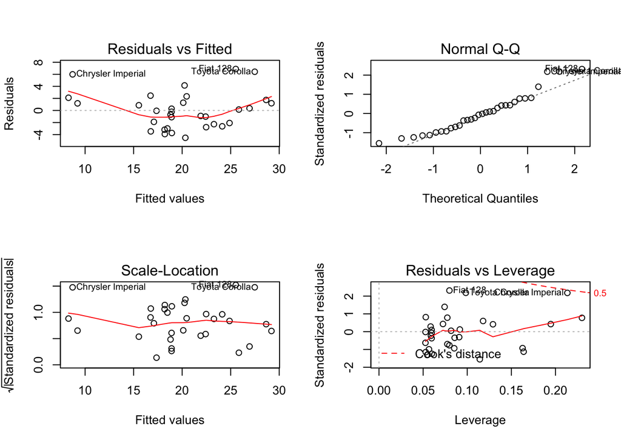